# Brockner-LayoffFairnessSurvivorReactions-1994-SJR.pdf

Converted from PDF `Brockner-LayoffFairnessSurvivorReactions-1994-SJR.pdf` · 20 pages · anchors: page `#pN`, block `#pN-bK`

Page 1

*Social Justice Research, VoL 7, No. 4, 1994*

### Perceived Fairness and Survivors' Reactions to Layoffs, or How Downsizing Organizations Can Do Well By Doing Good^

#### **Joel Brockner^**

In the 1980s and 1990s, job layoffs have pervaded the corporate landscape. Among the white-collar work force alone, Cameron *et al.* (1991) reported that, "More than 85% of the Fortune 1000 flrms... downsized... between 1987 and 1991, affecting more than five million jobs" (p. 58). Although layoffs have long been a topic of interest among social scientists, the goals of most previous investigations have been to identify the antecedents of layoffs (Comfleld, 1983) or the consequences of layoffs for the individuals whose jobs were eliminated (Jahoda, 1982). For both practical and theoretical reasons, however, it is important to understand the impact of layoffs on survivors' work behaviors (e.g., job performance) and attitudes (e.g., organizational commitment). Whether downsizing organizations achieve their goals of increased productivity depends to a great extent on the collective reactions of the remaining workers. Moreover, for theory-building purposes it is important to determine why survivors respond as they do.

Anecdotal evidence suggests that survivors' behaviors and attitudes are quite variable, both between and within downsizing organizations. Although most survivors are demotivated and demoralized by layoffs, for a sizable minority the layoffs have either little effect, or may even increase their work performance and/or organizational commitment. The studies described below are part of an ongoing program of research designed to explain the variability in survivors' reactions (see Brockner and Greenberg, 1990, and Brockner and Wiesenfeld, 1993, for reviews).

' A version of this paper was presented at the Stuckenberg Conference on Social Policies and

Research on Human Values, Washington University, St. Louis, Missouri, 1992. ^Columbia University, New York, New York 10027.

345

0885-7466/94/1200-0.t4.'iS07.U0/ü C 1994 Plenum Publishing Corporation

Page 2

**346 Brockner**

One particularly important determinant of survivors' reactions is the perceived fairness of the layoffs. Philosophers and psychologists have suggested that fairness and justice are central themes of social life. As Rawls (1971) put it, "Justice is the flrst virtue of social institutions...laws and institutions no matter how efficient and well-arranged must be reformed or abolished if they are unjust" (p. 3). Deutsch (1985) noted that issues of justice "may arise whenever something of value is scarce and not everyone

can have what he wants, or whenever something of negative value (a cost, a harm) cannot be avoided at all" (p. 1).

Survivors' fairness perceptions depend on the broader context in which the layoff occurred. Contextual factors include (i) aspects of corporate culture that affect survivors' expectations of how they will be treated by the organization, (ii) whether the organization tried to avoid layoffs, and (iii) actions taken by other organizations within the flrm's reference group. Specifically, survivors are more likely to experience unfairness (i) if the layoffs were unexpected in light of the prevailing corporate culture, such as in a paternalistic organization known for its high level of commitment to its work force, (ii) if the layoffs were perceived to be avoidable, and (iii) if the layoffs were more severe than those occurring in other organizations within the firm's reference group.

Survivors' justice judgments also depend upon the distributive and procedural methods that organization used to plan and implement the layoffs. Distributive determinants of justice—^pertaining to the fairness of the *outcomes* associated with the layoff—include the extent to which the organization provided concrete assistance to layoff victims, in the form of severance pay, outplacement counseling, and continuation of health insurance and other benefits; survivors are more likely to view the layoffs as unfair if the organization did little in the way of providing concrete forms of assistance.

Procedural justice refers to the fairness of the processes that the organization used to conduct the layoffs. Inspired by the important work of Thibaut and Walker (1975), and later Leventbal *et ai* (1980), procedural justice researchers initially focused on structural aspects of the resource

allocation decision process, such as whether individuals were allowed input into the process (i.e., Thibaut and Walker's notions of process control and decision control), whether consistent methods were employed, and whether opportunities to correct the decision were present. More recently, it has been suggested that procedural justice depends on factors other "than the formal properties of procedures used in making decisions. In addition, people focus on how decision makers conduct themselves during the enactment of the decision-making procedure" (Tyler and Bies, 1990, p. 78). Two aspects are central to this interactional or interpersonal aspect of procedural

Page 3

#### **Perceived Faimess and Reactions «o LayofTs 347**

justice: (i) whether individuals are provided a clear and adequate account

of the reasons underlying the resource allocation decision, and (ii) whether the affected parties are treated with dignity and respect during the implementation of the decision.

Thus, survivors' faimess judgments depend on tbe structural and interpersonal aspects of procedural justice. For example, survivors are more hkely to view the layoff as unfair if they have been provided little advance notice, if management has not provided a cogent explanation of why the layoffs were necessary and how they will help tbe organization to move forward, if they had little input into the various aspects of tbe downsizing decision, and if they were treated in an interpersonally inconsiderate fashion by those responsible for the implementation of tbe layoffs; see Brockner and Greenberg (1990) for further discussion of tbe determinants of survivors' perceptions of faimess.

Based upon theory and research in nonlayoff domains, I offer the following working hypothesis; In general, the more survivors perceive the layoff as unfair, the more likely is the layoff to have adverse effects on their work behaviors (e.g., motivation) and attitudes (e.g., organizational commitment). Said differently, by bandling layoffs in ways tbat survivors perceive to be fair (i.e., by doing good), downsizing organizations are more likely to elicit survivor reactions tbat promote tbe institution's goals (i.e., the organization can do well).

The working hypothesis is straigbtforward and, most would even say, obvious. The present article takes tbe working hypothesis as its point of departure, in an attempt to cast the role of perceived fairness in a more interesting and theoretically important light. For example, we have examined the reciprocal relationship between perceived fairness and survivors' reactions; that is, just as fairness may help explain some of tbe variability in survivors' reactions, the study of survivors' reactions may address issues of more basic theoretical interest in tbe justice literature. Tbe remainder of the chapter (i) raises some questions witb not-so-obvious answers, (ii) discusses theoretical underpinnings tbat may sbed light on tbese questions, (iii) reports empirical evidence in response to tbe questions, (iv) considers practical implications of the findings, and (v) offers suggestions for future research.

**QUESTION** 1: **HOW** DO DISTRIBUTIVE AND PROCEDURAL **JUSTICE COMBINE TO** INFLUENCE SURVIVORS' REACTIONS?

Early theorizing on justice focused on tbe fairness or favorability of the outcomes of the exchange relationship. For example, equity theory pos-

Page 4

**348 Brockner**

its that workers' satisfaction and motivation will decline if they believe that their outcome-to-point ratio is less than that of co-workers in their reference group (Adams, 1965). More recent research suggests that perceptions of procedural justice influence individuals' reactions to the resource allocation decision (e.g.. Lind and Tyler, 1988). In short, distributive and procedural justice both matter. However, it is important to understand the way(s) in which distributive fairness/favorability and procedural justice combine to influence individuals' reactions to resource allocation decisions.

Several theoretical perspectives suggest that distributive (outcome) and procedural (process) justice will interact to influence survivors' reactions, such that outcomes will have less impact on sui"vivors' reactions when procedural justice is high rather than low. Organizational life provides various outcomes or rewards to its members. Some of these rewards are material, e.g., pay and upward mobility, wbereas others are more social/psychological, e.g., feeling accepted and valued. If the layoff is perceived to be procedurally fair, then survivors should feel reassured that, *over time,* they will receive their share of desired outcomes. As a result, their work attitudes and behaviors should be less affected by distributive fairness (or outcome favorability) in tbe *current* situation. However, if the layoff is perceived to be procedurally unfair, then survivors sbould be less certain about how the organization will behave in the future, and, in particular, whether the organization can be trusted to deliver to survivors their share of desired outcomes. Put differently, procedural unfairness causes survivors to believe that "all future bets are off," shifting their attention to the present, and the fairness (or favorability) of the outcomes received in the present.

These hypotheses were tested in three samples of layoff survivors in different downsizing organizations (Brockner, 1990; Brockner, Konovsky *et ai,* 1994). Respondents were drawn from different industries (telecommunications, financial services); furthermore, line workers, first level supervisors, and middle managers took part. All participants completed measures of outcome fairness/favorability and procedural justice. For example, in one sample the outcome measure was survivors' perceptions of how well the organization had provided concrete assistance to those who were laid off (e.g., severance pay, outplacement counseling). One of the procedural justice measures was survivors' perceptions of how clearly management had explained the reasons for the layoffs. The dependent variable was survivors' organizational commitment. Consistent results emerged across all three settings. As shown in Table I, when procedural fairness was relatively low, outcome fairness (or favorability) was positively and significantly related to survivors' organizational commitment. However, when procedural fairness was relatively high, the relationship between perceived outcomes and or-

Page 5

**Perceived Fairness and Reactions to** LayolTs 349

ganizational commitment was nonsignificant. Conceptually analogous interaction effects have been obtained in several laboratory experiments (Cropanzano and Folger, 1989; Folger and Martin, 1986; Folgerei a/., 1983; Greenberg, 1993). The laboratory results are encouraging given the questionable internal validity of the results from the field studies.

The interaction effect has important practical implications for managers faced with the difficult task of planning and implementing layoffs. Although outcome and procedural factors seem functionally equivalent—as indicated in Table I by their effects on survivors' organizational commitment—there is at least one key difference bet%veen the two. Procedural fairness (e.g., giving clear explanations of the reasons for the layoffs) usually entails lower *economic* costs to the organization than does outcome fairness/favorability (e.g., providing concrete assistance such as severance pay and outplacement counseling). *This is not to say that downsizing organizations can simply ignore the determinants of outcome fairness.* If the organization offered little or no concrete sources of assistance, it is unlikely that procedural justice would compensate for the absence of distributive justice. From a cost-effectiveness perspective, however, reasonably adequate concrete caretaking coupled with high levels of procedural justice in implementing the layoffs may be the most prudent way to manage survivors' reactions. The cost-effectiveness of procedural justice has been demonstrated in other significant organizational change situations, such as the introduction of pay cuts (Greenberg, 199na).

The interactive effect of outcome fairness/favorability and procedural justice raises important questions for further research. If the layoffs are

handled in a procedurally fair manner, then sur%'ivors are more likely to feel that they will receive their share of desired outcomes in their future exchanges with the organization. Left unspecified was the precise nature of the "desired outcomes." According to the instrumental version of procedural justice theory (Thibaut and Walker, 1975), desired outcomes refer to tangible and material benefits, such as adequate pay, benefits, and promotion possibilities. According to the group-value theor)' of procedural jus-

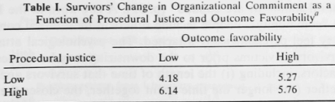

NOTE: complex table shown as an image of the PDF; the text below is a rough machine extraction and may be mis-aligned.

**extracted text (unreliable layout)**

"Scores could range from 1-11; lower scores reliccl a greater decline in

organizational commitment relative to the prclayoff period.

Page 6

**350 Brockner**

tice (Lind and Tyler, 1988), desired outcomes include enhanced self-esteem and a clear sense of self-identity, which may or may not result from the receipt of tangible and material beneflts. The present studies did not address this distinction. Hence, further research is needed to specify the conditions under which (or the people for whom) desired outcomes are defined in material vs. more social/psychological terms.

**QUESTION 2: UNDER WHAT CONDITIONS DOES FAIRNESS HAVE MORE** VERSUS LESS OF AN IMPACT ON SURVIVORS'

REACTIONS?

Although fairness is an important determinant of survivors' reactions, it is likely to be more influential under certain circumstances than others. All layoffs include three parties: (i) the downsizing organization, (ii) the individuals who are laid off (layoff victims), and (iii) the survivors. Basic theory and research in interpersonal justice suggest that survivors' prior relationship with each of the other two parties will moderate the effect of fairness on survivors' reactions (Lerner, 1980; Lind and Tyler, 1988).

**Survivors' Prior** Relationship with Layoff Victims

Deutsch (1985) coined the term "scope of justice," referring to the extent to which people include others in their moral community. People are more apt to believe that principles of fairness apply to social entities who are included in, rather than excluded from, their moral community. Deutsch suggests that the notion of scope of justice may help answer an important question raised by Lerner (1980): If justice considerations are such an important aspect of social life, why is it that people sometimes will tolerate unfair treatment meted out to others (i.e., victims)? According to Deutsch (1985), one of the ways in which an individual may tolerate injustice is by excluding "the victim from his deflnition of the community in which his moral standards are applied" (p. 59). A key word in the Deutsch quotation is "community." People include others in their moral community to whom they feel psychologically attached. The psychological attachment of layoff survivors to victims prior to the downsizing may be influenced by numerous factors, including (i) the length of time that survivors and victims worked together (the longer the time spent together, the closer the attachment), (ii) the nature of their work relationship (e.g., the greater their task interdependence, the closer the attachment), and (iii) the degree of atti-

Page 7

#### **Perceived Faimess and Reactions to Layoffs 351**

tudinal (or other forms of) similarity between the survivors and victims (the greater the similarity, the closer the attachment).

The prediction that perceived fairness more strongly influences survivor' reactions when they felt greater prior attachment to the layoff victims was examined in two field studies and in a laboratory experiment (Brockner *et ai,* 1987, 1992). Prior attachment was measured in the fleld studies by

having survivors rate the closeness of their professional and personal relationships with the layoff victims. Prior attachment was manipulated in the laboratory experiment by varying survivors' attitudinal similarity with the layoff victim. Faimess was operationalized in both distributive and procedural ways. Dependent variables included perceived fairness, organizational commitment, and work performance. Across settings and dependent variables, the hypothesis was supported. Table II reveals the results on the organizational commitment measure in one of the fleld studies (see the top half of Table II) and the perceived fairness measure in the laboratory experiment (see the bottom half of Table II). In both instances, the operationalization of perceived faimess had a stronger impact on survivors' reactions when they were more psychologically attached to the layoff victims. Most striking was the tendency for survivors to have particularly negative reactions when they felt attached to victims who were treated unfairly.

**Survivors' Prior Commitment** to the Organization

According to the group-value theory of justice (Lind and Tyler, 1988), individuals value their relationships with people, groups, and social institutions to fulflll higher order social/psychological needs. It is through relationships that people develop a sense of self-identity and feelings of self-worth (Festinger, 1954; Tajfel and Turner, 1979). Perceived faimess (unfaimess) by the other party to the relationship symbolizes to people

**Table II.** Survivors' Reactions as a Function of Prior Attachment to

Layoff Victims and Fairness

[output not shown]

NOTE: table converted from PDF layout to HTML text; cell boundaries are reconstructed. See PDF if exact alignment matters.

Page 8

**352 Brockner**

that they are (not) valued and respected, thereby facilitating (impeding) the development or maintenance of tbeir self-identity and self-worth.

This reasoning suggests that people wbose organizational membership has more self-definitional and self-evaluative implications (i.e., employees who are more committed to the organization) will be more influenced by the perceived fairness of tbe organization's bandling of tbe layoffs. To evaluate this possibility, Brockner *et al,* (1992) had survivors indicate their loyalty to the organization prior to the layoff. Survivors also rated the fairness of the basis that the organization used to keep certain individuals and lay off others (e.g., seniority, merit). Dependent variables included changes in organizational commitment and work effort, relative to before the layoffs. As predicted, and as shown in Table III, perceived fairness was a stronger predictor of the reactions of survivors wbo felt more loyal to the organization prior to the layoffs. Tbe most striking tendency was for survivors to respond negatively if they felt loyal to tbe organization beforeband but felt tbat tbe organization bad bandied tbe layoff unfairly.

Brockner *et al,* (1992) obtained similar results in a completely different domain; citizens' reactions to their encounters with legal authorities. Residents of Chicago rated their support for tbe police and tbe courts. One year later, tbey indicated wbetber tbey bad bad any dealings witb tbose institutions in tbe previous year, and if so, bow fairly they felt tbat tbey had been treated during the encounter. They also rated tbeir current level of loyalty to these legal institutions. Among tbose individuals who previously were more supportive of the police and courts, tbere was a marked relationsbip between tbe perceived fairness of tbeir treatment and tbe cbange in their level of loyalty. Most notable was tbe tendency for previously supportive citizens to express a sharp decline in loyalty if tbey felt tbat tbey bad been treated unfairly during tbeir encounters witb tbe legal institutions. In contrast, the opinions of individuals wbo were less supportive of tbe institutions at tbe outset did not vary as mucb as a function of perceived fairness. Thus, among layoff survivors as well as citizens who had recently dealt with the legal system, tbe bigber tbey were (as indicated by

**Table III.** Survivors' Change in Organizational Commitment

as a Function of Prior Commitment and Perceived Fairness

[output not shown]

NOTE: table converted from PDF layout to HTML text; cell boundaries are reconstructed. See PDF if exact alignment matters.

Page 9

#### **Perceived Fairness and Reactions to Layoffs 353**

**their prior** loyalty), the harder they fell (when they perceived the institution to have acted unfairly).

Research that explores moderators of the relationship between perceived fairness and survivors' reactions to layoffs sen-es several important theoretical and practical purposes, first, it helps to refine the explanation of the variability in survivors' reactions. Rather than simply demonstrating that survivors' reactions vary as a function of the fairness of the layoff, the findings described in Tables II and III identify some of the conditions under which fairness is more or less influential. Moreover, the studies described in these tables show the extemal generalizability of basic theorizing in the justice literature, for example, the application of the group-value model

(Lind and Tyler, 1988), to the survivor context. Finally, the results suggest the conditions under which it is especially important to handle layoffs in ways survivors perceive to be fair (or at least not unfair). Greenberg (1990b) suggests that managers need to do more than act fairly; to accomplish their objectives they must *he perceived* as having acted fairly. If survivors and victims previously were part of a cohesive work unit (in which case survivors are likely to feel close to the victims), or if the organization had a paternalistic corporate culture (which fostered high levels of employee commitment), then the downsizing organization may need to work even harder than usual to ensure that survivors perceive the layoff to be fair.

#### **QUESTION 3: HOW DOES PERCEIVED FAIRNESS AFFECT THE**

**IMPACT OF CHANGES IN WORKING** CONDITIONS ON

**SURVIVORS'** REACTIONS?

Layoffs often coincide with numerous changes in working conditions, which have been shown in nonlayoff situations to influence individuals' work attitudes and behaviors. For example, survivors often feel greater job insecurity than they did prior to the layoffs. In addition, the volume of their workload may be different than before. Because downsizing organizations generally are quicker to eliminate workers than work, survivors may be required to do more than they did prior to the layoff. The intrinsic enjoyability of their work may be affected by layoffs. Some survivors may have been asked to accept different responsibilities, thereby heightening the perceived variety (and thus the intrinsic quality) of their jobs. Others may find that management's anxieties led to greater restrictions and controls being placed on their jobs, thereby decreasing (positive feelings of) autonomy.

Survivors' career prospects within the organization may also be affected by layoffs. For example, suppose that a group of first-level supervisors planned on being promoted soon to the next level in the managerial

Page 10

**354 Brockner**

hierarchy. Suppose further that the organization eliminated all or many of the positions in that next level in the hierarchy during its most recent cutbacks. In this example the surviving first-level supervisors are likely to be uncertain about their career possibilities within the organization. Yet another source of new information which may influence survivors is the reactions of their fellow survivors to the layoffs. If fellow survivors reacted negatively—e.g., if they acted as if management is not to be trusted, or that the organization is in decline—then survivors' productivity and morale should decrease. However, if fellow survivors react in ways that are more upbeat, then survivors' reactions should be more positive as well. In general, survivors' reactions to the changes in working conditions should depend on whether they experience the changes as threats or opportunities. The more that the changes are believed to be threats, the more likely are survivors to respond adversely to the layoffs.

Implicit in Question 3 are the notions that (i) changes in working conditions may have a greater impact on survivors' reactions under certain conditions than others, and (ii) perceived fairness may be one of the factors that moderates the impact of changes in working conditions on their reactions to the layoffs. Note the subtle difference between Questions 2 and 3. In Question 2, the point of departure was the hypothesis that fairness affects survivors' work attitudes and behaviors. Research addressing Question 2 idenfified factors that moderate the relationship between fairness and survivors' reactions, such as their prior attachment to the layoff victims and prior commitment to the organization. In Question 3, we began with the assertion that perceived changes in working conditions will influence survivors' reactions. Research related to Question 3 examines whether perceived fairness moderates the effect of changes in working conditions on survivors' reactions to the layoff.

Qne important change is the nature of survivors' jobs (Sutton, 1990). As stated above, some survivors may feel that their job has become less intrinsically interesting, whereas others may perceive that their job has become more enjoyable. Much empirical research (performed in nonlayoff field settings) has demonstrated that employees' work motivation, job satisfaction, and organizational commitment are positively related to the intrinsic enjoyability (or *content)* of their jobs (Hackman and Qldham, 1980). Moreover, the relationship between perceived job content and workers' attitudes and behaviors has been shown to be stronger when the work *context* is relatively favorable (Qldham, 1976). For example, the work context is more favorable when compensation is adequate rather than inadequate, or when relationships with co-workers or supervisor are pleasant rather than unpleasant. In explaining the interactive relationship between job content and job context, Qldham (1976) suggested that an unfavorable context

Page 11

#### **Perceived Fairness and Reactions to LayofTs 355**

"might disturb or distract the employee to such a degree that he is unable to...respond to the characteristics of a complex [i.e., enjoyable] job. Rather, the individual...is likely to expend much energy and attention merely attempting to cope with or resolve [the contextual difflculties]" (p. 561).

The results of several laboratory experiments on intrinsic motivation also demonstrate that context moderates the relationship between perceived job content and individuals' task attitudes/behaviors. In one study (Sansone,

1989), subjects worked on a puzzle and evaluated its characteristics. One dimension—dubbed "competence valuation"—was the extent to which doing well on the task was important to participants. Hackman and Oldham's

(1980) Job Characteristics Model suggests that tasks should be perceived as intrinsically enjoyable when competence valuation is relatively high. Sansone discovered that the relationship between competence valuation and participants' task enjoyment depended upon an experimental manipulation of whether subjects had chosen the activity to work on (choice condition), or

had the identical activity assigned to them (no-choice condition). Competence valuation was much more positively related to task enjoyment in the choice than no-choice condition. Conceptually similar results were reported by Ryan (1982). These flndings seem related to those previously described from the job design literature if we make the reasonable assumption that context favorability was higher in the choice than no-choice condition. Moreover, the Sansone (1989) and Ryan (1982) studies may help to deflne what is meant by context "favorability": the extent to which the situation facilitates (versus thwarts) individuals' perceptions of control.

In sum, (i) layoffs often are associated with changes in job content, and (ii) context favorability has been shown in previous research to moderate the impact of job content on individuals' work attitudes/behaviors, such that they are more influenced by the changes in job content when the context is relatively favorable. Therefore, the reactions of layoff survivors to changes in job content should depend upon the favorability of the context in which the change in job has occurred. Content favorability, in turn, may be influenced by the factors that affect survivors' judgments of the fairness of the layoff. The more survivors judge the layoff to be fair, the more likely they are to experience the context as favorable, and therefore, the more likely it is that they will be affected by changes in the content of their jobs.

This hypothesis was tested in a laborator>' experiment and in a fleld study (Brockner, Wiesenfeld *et ai,* 1993). In the laboratory experiment, all participants worked on a task designed to be moderately interesting prior to witnessing the layoff of a co-worker. Half of the participants observed a layoff that was handled relatively fairly (high-fairness condition), whereas the remaining half viewed a layoff that was implemented unfairly (low-fairness condition). After the layoff, all participants worked on another task.

Page 12

**356 Brockner**

For half of them, the task was designed to be more intrinsically interesting then the flrst task (better condition), whereas for the remaining half the task had become less interesting (worse condition). Dependent variables included measures of the perceived importance of the study, and participants' overall reactions to having taken part. The predicted interaction between job content and context emerged. As shown in the bottom half of Table IV, the tendency for people to respond more favorably in the better than worse condition was more pronounced when the layoff was handled fairly rather than unfairly.

In the field study survivors completed a survey measuring the independent variables of perceived change in the nature of their job relative to before the layoff, and perceived fairness in how the layoff was handled. The dependent variable was change in organizational commitment. An interaction effect emerged which was generally similar in form to tbe one observed in the laboratory experiment. The top half of Table IV reveals that the relationship between perceived job content and organizational commitment was more pronounced among sui"vivors who felt that the layoff had been handled relatively fairly.

The results shown in Table IV provide further evidence on how downsizing organizations may do well by doing good. Note the consistent finding in the Better condition in both studies: Survivors reacted more favorably when layoff fairness was relatively high. This finding implies that if survivors' jobs are redesigned to be more intrinsically interesting, the organization is much more likely to reap tbe benefit (in the form of enhanced survivors' reactions) if the layoff is viewed as relatively fair.

One other finding from the field study is particularly noteworthy. To test the hypothesis that the uncertainties associated with layoffs make survivors hungry for information about the appiopriate ways to think and act (and therefore susceptible to influence by the reactions of their fellow

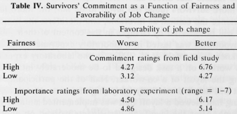

NOTE: complex table shown as an image of the PDF; the text below is a rough machine extraction and may be mis-aligned.

**extracted text (unreliable layout)**

Page 13

#### **Perceived Fairness and Reactions to LayofTs 357**

survivors), survivors indicated bow tbe co-workers in tbeir immediate work groups had been affected by the layoffs. Sample items included, "My co-workers have worked extra hard since tbe layoffs began," and "My co-workers have been quite mistrustful of top management since the layoffs began" (reverse scored). In fact, survivors' reactions were significantly related to their perceptions of their co-workers' reactions. This relationship was moderated, moreover, by perceived fairness; tbe more survivors viewed the layoffs as having been handled unfairly, the stronger was the relationship between tbeir co-workers' and tbeir own reactions to the layoffs. Thus, witbin the same group of survivors it was found that greater unfairness caused their reactions to be *less* affected by perceived change in the nature of their jobs (see Table IV), and *more* influenced by the perceived reactions of their fellow surviving co-workers, relative to those who viewed the layoff as more fair. Taken together, tbese findings are consistent with Oldbam's (1976) suggestion tbat unfavorable contexts caused people to become preoccupied witb coping with the threat inherent to the situation. Thus, in response to tbe uncertainty generated by unfair layoffs, survivors may have tried to cope by attending to coworker cues concerning the appropriate ways to respond; perceived change in the content of their jobs may bave been less informative about how to cope with the unfairness, leading survivors to be less influenced by this factor than they would be if tbey viewed tbe layoff as fair.

FUTURE RESEARCH DIRECTIONS

The straightforward hypothesis that tbe variability in survivors' reactions depends on perceived faimess led to more interesting questions concerning (i) how the various forms of justice combine to influence survivors, (ii) the factors tbat moderate the effect of fairness on survivors, and (iii) bow fairness moderates the effect of changes in working conditions on survivors' reactions. The findings described above raise many questions tbat need to be addressed in future research. Two of these questions are considered.

**Future Research Question 1: Do the** Determinants of Survivors'

**Reactions Lend** Themselves to a Unified Explanation?

Most (and possibly all) of tbe results reported above are consistent with Steele's (1988) provocative theory of self-affirmation. According to this viewpoint, people are motivated to see tbemselves "as adaptively and mor-

ally adequate, that is, competent, good, coherent, unitary, stable, capable

Page 14

**358 Brockner**

of free choice, capable of controlling important outcomes and so on" (p. 262). Evidence contradicting these self-views is experienced as a threat to self-integrity, motivating the person to change their beliefs or behaviors to restore self-integrity. One virtue of self-affirmation theory is that it may provide a common explanation of the effects of specific processes such as dissonance, reactance, learned helplessness, and inequity. Although the events triggering these psychological states differ, Steele (1988) suggests **that** their effects are mediated by a common mechanism: the threat they pose to the integrity of the self. For example, dissonance-arousing behaviors such as writing a counterattitudinal essay affect people by threatening their self-concepts of being coherent, unitary, and stable individuals. Reactancearousing conditions interfere with individuals' desire to feel that they are capable of free choice, and conditions promoting learned helplessness impede peoples' desires to see themselves as capable of controlling important outcomes.

If the effects of dissonance, reactance, learned helplessness, and the like reflect threatened self-integrity, the circumstances eliciting these states should be less impactful if people are given an opportunity for self-affirmation. Moreover, the self-affirming experience may be completely unrelated to the domain which produced the initial threat to self-integrity. For example, in several studies dissonance was elicited by having participants write a counterattitudinal essay out of their own free will (Steele, 1988; Tesser and Cornell, 1991). Typically, people exhibit greater attitude change in this situation, relative to when they are forced to write the counterattitudinal essay. However, when people were provided with a self-affirmation opportunity—e.g., if they completed a measure of personally meaningful values—then their level of attitude change was significantly reduced. Liu and Steele (1986) pretreated participants with uncontrollability experiences; replicating past research, the authors found an increase in anxiety, hostility, and depression. However, these tendencies were reduced when people had the self-affirming experience of completing a personally meaningful value survey.

It may be that the adverse effects on survivors of the unfairness associated with layoffs result from a threat to their self-integrity. When the downsizing organization acts unfairly, it implicitly signals its lack of respect for the personhood of victims and survivors, a notion consistent with the group-value model of justice (Lind and Tyler, 1988). If threat to self-integrity mediates the relationship between unfairness and adverse survivor reactions (e.g., reduced organizational commitment), then survivors' reactions should be particularly negative under conditions in which the self-integrity threat is relatively high. In fact. Table II showed that survivors reacted quite negatively when the layoff was unfair and they felt psychologically attached to the layoff victims. In the language of balance theory

Page 15

#### **Perceived Fairness and Reactions to Layoffs 359**

(Heider, 1958), survivors' attachment to the victims reflected a strong "unit relationship" between the two. Perhaps survivors experienced the unfairness meted out to the victims as if it had been directed towards them, producing a greater threat to self-integrity than if the unfairness had been directed towards victims to whom survivors did not feel as attached.

Table III revealed that survivors reacted adversely when they were relatively committed to the organization beforehand and felt that the layoff was handled unfairly. Prior commitment to the organization reflects a strong unit relationship between survivors and the organization. Thus, survivors may have experienced the organization's unfairness to be an extension of themselves having acted unfairly, causing a greater threat to self-integrity than if the unfairness had been initiated by an organization with whom survivors were not so closely identified.

Self-affirmation theory may also explain why fairness moderated the effect of change in job content on survivors' reactions (see Table IV). Qldham (1976) suggested that in unfavorable contexts, people become more preoccupied with coping with the threat evoked by the situation (and thus less responsive to job content). However, Qldham did not specify the nature of the threat elicited by unfavorable contexts. Perhaps it is individuals' selfintegrity that is threatened by unfavorable contexts.

Qne way to test the hypothesis that threatened self-integrity mediates the relationship between layoff unfairness and adverse survivor reactions is to vary whether presumably disaffirmed survivors are given the opportunity to restore self-integrity. That is, all participants should be exposed to conditions in which a threat to self-integrity has occurred, such as seeing victims with whom they identify treated unfairly. In the absence of the opportunity for self-affirmation, survivors should react negatively towards the organization, as in the Low Fairness/High Prior Attachment conditions in Table II. However, the reactions of survivors who are given the opportunity to selfaffirm should be far less negative. The self-affirming experience, moreover, may be unrelated to the context which initially threatened self-integrity. Perhaps having survivors express values of personal significance, or recalling a situation in which they performed well in some meaningful endeavor (Tesser and Cornell, 1991) may be sufficient to offset the negative effects of an unfair layoff administered to layoff victims to whom survivors feel attached.

Future Research Question 2: Why Don't Downsizing Organizations Act

Fairly More Often?

Research examining the effects of fairness on survivors poses a paradox. Qn the one hand, survivors' reactions generally are more beneficial

Page 16

#### **360 Brocitner**

to the organization if the layoffs are perceived to be fair. Executives responsible for planning and implementing layoffs probably are well aware of this fact. Moreover, many of the determinants of fairness are not economically costly, such as clearly explaining why the layoffs were necessary and treating people with dignity and respect. Winston Churchill was one world leader who recognized the cost-effectiveness of treating people fairly. The day after the attack on Pearl Harbor, Churchill sent a letter to the leaders of Japan declaring war. As Folger (1992) reported, "The letter ended with a very proper British closing, 'Your obedient servant,' and Churchill wrote of having been publicly castigated for using that expression" in the context of declaring war. To which Churchill responded, "When you have to kill a man it costs nothing to be polite."

Given all the reasons for downsizing organizations to handle layoffs fairly, it is reasonable to ask why they often fail to do so. Folger (1992) suggests that such paradoxical organizational behavior is not limited to layoff situations: "Precisely when, by attention to small details of humane treatment and common decency, a tremendous opportunity exists for earning the goodwill of employees,... employers will act so as to miss that opportunity and instead engender strong feelings of resentment" (p. 8).

Perhaps a simple legal/economic explanation may account for the failure of downsizing organizations to capitalize on the opportunity associated with handling layoffs fairly. A key aspect of treating people fairly is providing them with information, i.e., the details of *why* the layoffs were necessary, *what* alternatives were considered by the organization, and *how* the organization chose to retain certain employees while laying off others. However, downsizing organizations may fear that disgruntled layoff victims may use this information against them in the course of taking legal action against the organization.

Alternatively, the barriers to fair behavior by executives responsible for planning and implementing layoffs may be social/psychological in nature. Folger (1992) offers three such possibilities. First, the depersonalization of the layoff victims may facilitate the painful task of laying them off. Milgram (1974) discovered in his classic studies on obedience to authority that participants were more likely to inflict physical pain on innocent victims when they were more psychologically distant from the victims. By failing to treat victims with dignity and respect, i.e., by acting in an interpersonally unfair way, downsizing organizations may put psychological distance between themselves and the victims, thereby making it easier to accomplish the mission. Consistent with this speculation, survivors' reactions were relatively unaffected by perceived fairness when they were more psychologically distant from the layoff victims prior to the downsizing (see Table II). Indeed, survivors were much less likely to experience the low-

Page 17

#### **Perceived Faimess and Reactions to LajolTs 361**

faimess layoff as unfair when they were more distant from the layoff victims. Second, by distancing themselves from (or blaming) the layoff victims, the architects of the layoff may convince themselves that they will not suffer a similar fate. Viewing the layoff victims as unworthy (of fair treatment), **those who** remain may see themselves as deserving better than the harsh treatment which the victims received.

Third, just as the provision of clear and adequate explanations has symbolic value, so too might the avoidance of providing clear and adequate explanations. Recall Langer's (1978) classic study in which would-be linebreakers at a paper copying machine were more likely to gain the right of **way** if they said to the person making copies, "Would you mind if I go ahead of you? / *have some copying to do?* (italics added), than if they simply asked if they could go ahead without offering an "e.xplanation." Presumably, the person making copies was influenced by the symbolic value of having an explanation offered to him/her, and not by the substance of the explanation. After all, why else would requesters ask to use the machine unless they needed to make copies? Similarly, executives of downsizing organizations may balk at providing accounts of their actions because they believe that the very act of providing such information symbolizes a loss of power.

Future research needs to explore which of the various explanations (or others, for that matter) best accounts for the failure of organizations to maximize the faimess with which they handle layoffs or other unpopular resource allocation decisions. Such research should not only be of great theoretical importance but also help organizations overcome the barriers **that** prevent them from doing good, and hence, doing well.

ACKNOWLEDGMENTS

I thank Mel Lerner for organizing the conference and Batia Wiesenfeld for making constructive comments on an earlier draft.

REFERENCES

Adams J S. (1965). Inequity in social exchange. In Berkowitz, *L.* (ed.). *Advances in*

*Experimental Social Psychology.* Vol. 2. Academic Pre.ss. New York, pp. 267-299. Brockner, J. (1990). Scope of justice in the workplace; How sur\ivors react to co-worker

layoffs. /. *Soc. Issues* 46: 95-106. . . Brockner J and Greenberg, J. (1990). The impact of layoffs on sur%ivors: An organizational

justice perspective. In Carroll, J. S. (ed.). *Applied Social Psychology and Organizaiional Settings,* Erlbaum, Hillsdale, NJ, pp. 45-75.

Page 18

**362 Brockner**

Brockner, J., Grover, S., Reed, T., DeWitt, R., and O'Malley, M. (1987). Survivors' reactions

to layoffs: We get by with a little help for our friends. *Admin. Sei. Quart.* 32: 526-541. Brockner, J., Konovsky, M., Cooper-Schneider, R., Folger, R., Martin, C, and Bies, R. J.

(1994). The interactive effects of procedural justice and outcome negativity on the victims and survivors of job loss. *Acad. Manage. J.* 37: 397-409. Brockner, J., Tyler, T. R., and Cooper-Schneider, R. (1992). The influence of prior

commitment to an institution on reactions to perceived unfairness: The higher they are, the harder they fall. *Admin. Sei. Quart.* 37: 241-261. Brockner, J., and Wiesenfeld, B. (1993). Living on the edge (of social and organizational

psychology): The effects of job layoffs on those who remain. In Murninghan, J. K. (ed.), *Sociat Psychotogy in Organizations: Advances in Theory and Research,* Prentice-Hall, Englewood Cliffs, NJ, pp. 119-140. Brockner, J., Wiesenfeld, B., Reed, T., Grover, S., and Martin, C. (1993). The interactive

effect of job content and job context on the reactions of layoff survivors. /. *Pers. Soc. Psychot.* 64: 187-197. Cameron, K., Freeman, S. J., and Mishra, A. (1991). Best practices in white-collar downsizings:

Managing contradictions. *Acad. Manage. Exec.* 5: 57-73. Cornfield, D. B. (1983). Chances of layoff in a corporation: A case study. *Admin. Sei. Quart.*

28: 503-520. Cropanzano, R., and Folger, R. (1989). Referent cognitions and task decision autonomy:

Beyond equity theory. / *Appt. Psychot.* 74: 293-299. Deutsch, M. (1985). *Distributive Justice: A Sociat-Psychotogicat Perspective,* Yale University

Press, New Haven, *CT.* Festinger, L. (1954). A theory of social comparison processes. *Hum. Relat.* 7: 117-140. Folger, R. (1992). Ethical dimensions and paradoxes arising from mass layoffs. Paper

presented at the Society for the Advancement of Socio-Economics, Irvine CA. Folger, R., and Martin, C. (1986). Relative deprivation and referent cognitions: Distributive

and procedural justice effects. *J. Exp. Soc. Psychot.* 22: 531-546. Folger, R., Rosenfield, D., and Robinson, T. (1983). Relative deprivation and procedural

justice. / *Pers Soc. Psychot.* 45: 268-273. Greenberg, J. (1990a). Employee theft as a reaction to underpayment inequity: The hidden

costs of pay cuts. /. *Appt. Psychot.* 75: 561-568. Greenberg, J. (1990b). Looking fair: Managing impressions of organizational justice. In Staw,

B. M., and Cummings, L. L. (eds.). *Research in Organizationat Behavior,* Vol. 10, **JAI** Press, Greenwich, CT, pp. 111-157. Greenberg, J. (1993). Stealing in the name of justice: Informational and interpersonal

moderators of theft reactions to underpayment inequity. *Organ. Behav. Hum. Decision Proc.* 54: 81-103. Hackman, J. R., and Oldham, G. R. (1980). *Work Redesign,* Addison-Wesley, Reading, MA. Heider, F. (1958). *The Psychology of Interpersonal Retations,* Wiley, New York. Jahoda, M. (1982). *Emptoyment and Unemployment: A Social Psychotogicat Anatysis,* Academic

Press, New York. Langer, E. J. (1978). Rethinking the role of thought in social interaction. In Harvey, J. H.,

Ickes, W., and Kidd, R. E. (eds.). *New Directions in Attribution Research,* Vol. 2, Eribaum, Hillsdale, NJ, pp. 35-58. Lerner, M. J. (1980). *The Betief in a Just World: A Fundamentat Detusion,* Plenum Press, New

York. Leventhal, G. S., Karuza, J., and Fry, W. R. (1980). Beyond fairness: A theory of alloeation

preferences. In Mikula, G. (ed.). *Justice and Sociat Interaction,* Springer-Verlag, New York, pp. 167-218. Lind, E. A., and Tyler, T. R. (1988). *The Social Psychotogy of Procedural Justice,* Plenum Press,

New York. Liu, T. J., and Steele, C. M. (1986). Attributional analysis as self-affirmation. / *Pers. Soc*

*Psychot.* 51: 531-540. Milgram, S. (1974). *Obedience to Authority,* Harper, New York.

Page 19

#### **Perceived Fairness and Reactions to Layoffs 363**

Oldham, G. R. (1976). Job characteristics and intemal motivation: The moderating effect of

interpersonal and individual variables. *Hum. Relat.* 29: 559-569. Rawls, J. A. (1971). *A Theory of Justice,* Hanard University Press, Cambridge, MA. Ryan, R. M. (1982). Control and Information in the intrapersonal sphere: An extension of

cognitive evaluation theory. / *Pers. Soc. Psychol.* 43: 450-461. Sansone, C. (1989). Competence feedback, task feedback, and intrinsic interest: An

examination of proeess and eontext. / *Exper Soc. PsychoL* 25: 343-361. Steele, C. M. (1988). The psyehology of self-affirmation: Sustaining the integrity of the self.

In Berkowitz, L. (ed.). *Advances in Experimental Social Psychology,* Vol. 21, Academic Press, New York, pp. 261-302. Sutton, R. 1. (1990). Organizational decline processes: A social psychologieal perspective. In

Staw, B. M., and Cummings, L. L. (eds). *Research in Organizational Behavior,* Vol. 12, **JAI** Press, Greenwich, CT, pp. 205-253. Tajfel, H., and Tumer, J. (1979). An integrative theory of intergroup conflicts. In Austin, W.

G., and Worchel, S. (eds.). *The Social Psychology of Intergroup Relations.* Brooks/Cole, Monterey, CA, pp. 33-47. Tesser, A., and Cornell, D. P. (1991). On the confluence of self-processes. / *Exp. Soc. Psychol.*

27: 501-526. Thibaut, J., and Walker. L. (1975). *Procedural Justice,* Wiley, New York. Tyler, T. R., and Bies, R. J. (1990). Interpersonal aspects of procedural justice. In Carroll,

J. S. (ed.). *Applied Social Psychology and Organizational Settings,* Eribaum, Hillsdale, NJ, pp. 77-98.

Page 20